# 每週一圖作業範例

#### 環境設定

以下為老師執行時一定會存在的環境設定

```r
Sys.setlocale("LC_ALL","Chinese")  #解決中文亂碼問題
```

```
## [1] "LC_COLLATE=Chinese (Simplified)_China.936;LC_CTYPE=Chinese (Simplified)_China.936;LC_MONETARY=Chinese (Simplified)_China.936;LC_NUMERIC=C;LC_TIME=Chinese (Simplified)_China.936"
```

```r
library(dplyr); library(stringr); library(ggplot2); library(plotly); library(lubridate); library(readr); library(tidyr); library(showtext);library(ggthemes);
library(grDevices) # 不同顏色模型代碼的呈現及轉換
library(scales) # show_col()螢幕立即顯示顏色
library(colorspace) # 調色盤選擇及ggplot應用工具
library(shinyjs) # 支援套件


font_add("QYuan","cwTeXQYuan-Medium.ttf") # 新增字體
showtext_auto(enable=TRUE) #啟用字體
theme_set(theme_classic())
knitr::opts_chunk$set(out.width='80%', fig.asp=.75, fig.align='center', fig.showtext=T)
```

#### 資料處理

此部份在做：

- 原始Rda資料引入（即引入**dataList**物件）；
- 資料清理成作圖用graphData物件。

請將你最原始的資料連同作業一起上傳到作業上傳網址：  
* 若「原始資料為網頁下載」，且下載指令寫在data cleaning chunk裡的話，可以不用上傳「資料」。  
* 若原始資料有很多個檔案，請先引入成data frame並存在「一個」.Rda檔裡上傳（如`example_data.Rda`檔）。

資料檔引入到進入作圖前的資料處理請寫在下面區塊，分二部份：

- 資料處理
- 作圖用資料物件生成

```r
Sys.setlocale("LC_ALL","Chinese")               #解決中文顯示亂碼問題
```

```
## [1] "LC_COLLATE=Chinese (Simplified)_China.936;LC_CTYPE=Chinese (Simplified)_China.936;LC_MONETARY=Chinese (Simplified)_China.936;LC_NUMERIC=C;LC_TIME=Chinese (Simplified)_China.936"
```

```r
library(readr)
cityCost <- read_csv("http://www.nccc.com.tw/dataDownload/Gender/BANK_MCT_ALL_GD.CSV")
```

```r
#View(cityCost)
#unique(cityCost$地區)

cityCost %>% mutate(
  地區=factor(地區)
)->cityCost

#str(cityCost$地區)



filter(cityCost, 地區=="台北市"|地區=="高雄市")  -> BigCityCost      #篩出高雄市及台北市
#BigCityCost %>%  View()
#str(BigCityCost)


BigCityCost %>%                                                      #改年月日
  mutate(
    年月=年月 %>%
      stringr::str_extract_all("[:digit:]+") %>%
      purrr::map_chr(
                 function(x) {
                   x1=as.integer(x[[1]])+1911
                   x[[1]]=as.character(x1)
                                stringr::str_c(x,collapse="-")
                 }
                 ),
    年月日=stringr::str_c(年月,"01",sep="-"),
    西元年月日=lubridate::ymd(年月日)
  ) ->BigCityCost

BigCityCost[-1] ->BigCityCost
#BigCityCost %>% View()

BigCityCost  %>%  group_by(
  地區
) %>%   mutate(
    食的消費=(sum(`食品餐飲類男性[金額，新台幣]`) +sum(`食品餐飲類女性[金額，新台幣]`))/(67*2),
    衣的消費=(sum(`衣著飾品類男性[金額，新台幣]`)+sum(`衣著飾品類女性[金額，新台幣]`))/(67*2)
) %>% ungroup()->BigCityCost_EnC

#BigCityCost_EnC %>%  View()
BigCityCost_EnC %>% gather(
  食的消費,衣的消費,
  key="食物種類",value = "消費金額"
) ->  BigCityCost_EnC_gather





# 作圖用資料物件生成：處理好可進行作圖的資料請存在一個名為graphData的list物件裡
graphData <- list()
graphData<-BigCityCost_EnC_gather
#graphData %>% View()
```

#### 繪圖程式

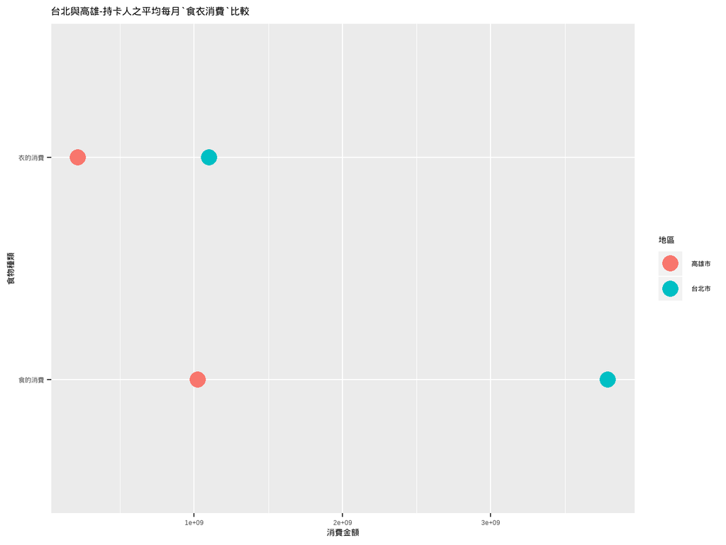

```r
graphData %>% mutate(
  地區=factor(地區,levels=c("高雄市","台北市"))
)%>% ggplot(
  aes(x=食物種類,y=消費金額,color=地區)
  )+
  geom_point(size=5)+
  theme_gray()+
  ggtitle(label = "台北與高雄-持卡人之平均每月`食衣消費`比較")+
  coord_flip()
```

#### 設計說明

說明想傳達的訊息（必要）及設計想法（非必要）。寫在*之後*

*圖形表達: 本圖清楚地表現了高雄及台北-兩大台灣最繁榮的城市，在生活消費上“食”和“衣”的差異。

*概念核心: 原始資料為台灣六都中，針對持有信用卡人士，做出的各項消費統計。 而我認為持有信用卡，代表消費者屬於有一定消費水準的人士，再加上台北及高雄的都市開發相對於其他縣市，算是非常突出，用信用卡消費金額更能凸顯–“兩地中皆有一定消費水準的人們，在兩地的基本消費差異”。

*資料篩選作法: 在繪圖前，將資料篩出並算出台北及高雄、食物及衣服的平均每月消費金額，從而繪圖。

*補充: 1.高雄地理位置偏南方，且大眾普遍認為較有熱情，因此選用紅色，台北則為其對比色。 2.計算部分已於EXCEL再次驗算過。 3.某些檢查變數結構以即檢查資料等問題，已處理並加上“井字號”，讓程式可以先跑出結果。 4.消費統計日期自103年1月至108年7月。